# Ford Gobike Data Analysis

## by Mohamed Abuelmaaref

## Investigation Overview

> The overall goals of incistigating this dataset is to find relations and intersections between features that affect the trip numbers and therefore affect the buseness side of the company and to understand the patterns of users to target them and bring them to the group of the most profitable (business wise) group of people.

## Dataset Overview

> The dataset that I am doing analysis on is Ford GoBike dataset about trips recordings of year 2019 february month. Which has records for each trip in details, Time, location, user type, gender, age, and trip duration.

## Distribution of Trips Throughout The Days of The Week

> I have found out that throughout the days of week the number of trips in weekends is less than the rest of the days, While on the other hand the average duration of the trips in the weekends is higher than the rest of the days.

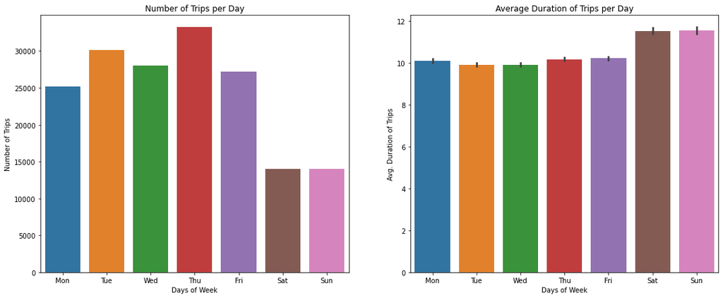

## Gender Based Analysis of Trips Throughout The Week

> Males have a much higher trips over the week than the other genders, while on the other hand they have the less average trip duration. Females and Other gender tend to spend more time in trips.

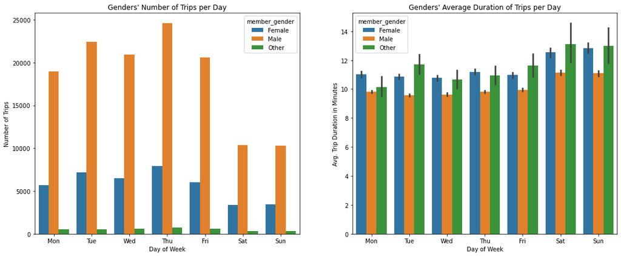

## User Type Analysis

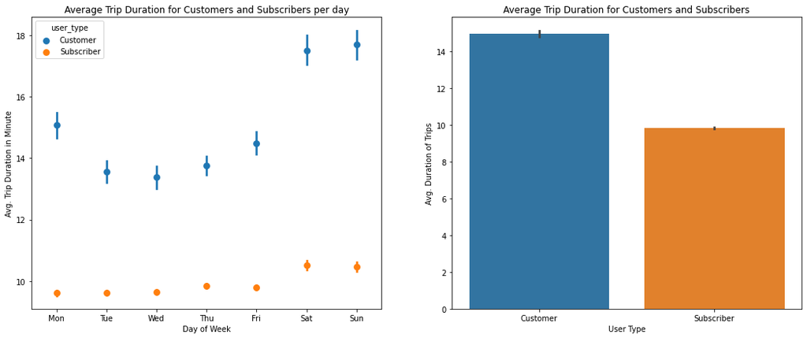